# ATiG 2026: Mendelian randomisation — answers

8 October 2026 · About 60 minutes · Work in pairs

We will use BMI and coronary heart disease GWAS results to estimate a causal effect, then check what happens when the MR assumptions fail.

Run the cells in order. Change the settings marked `# TRY` and discuss the questions. The data are included. [Open in Colab](https://colab.research.google.com/github/bvilhjal/ATIG_2026/blob/main/teaching_days/2026-10-08/MR/MR_practical_answers.ipynb) and choose File → Save a copy in Drive. Use a Python 3 runtime.

## Setup

```python
import io
import numpy as np
import pandas as pd
import matplotlib.pyplot as plt

plt.rcParams['figure.dpi'] = 110
pd.set_option('display.precision', 4)
```

[output not shown]

## Q1. Explore the data

These are genome-wide significant BMI GWAS variants ($P<5\times10^{-8}$), LD-clumped to retain approximately independent signals. Each row is one SNP.

- `effect_allele`, `other_allele`: the original allele coding in the supplied GWAS data.
- `bmi_effect`, `bmi_se`: BMI effect and standard error, in SD units per effect allele.
- `chd_effect`, `chd_se`: CHD effect and standard error, in log odds per effect allele.

BMI and CHD effects refer to the same effect allele; the allele labels already match in these data. We retain the original signs. A standard error describes uncertainty in the estimate, not variation between people.

Look at Tables 1 and 2. What does a negative BMI effect mean? Why must both GWAS use the same effect allele? Which MR assumption does a large association statistic support?

```python
print('Table 1. The first five SNPs and their GWAS associations.')
display(data.head())  # First five SNPs.

bmi_effect = data['bmi_effect']
bmi_se = data['bmi_se']
chd_effect = data['chd_effect']
chd_se = data['chd_se']

# Approximately chi-square (1 df) under the null of no SNP–BMI association.
association_statistic = (bmi_effect / bmi_se)**2

print(f'Smallest association statistic: {association_statistic.min():.1f}')
```

```
Table 1. The first five SNPs and their GWAS associations.
```

|  | snp | effect_allele | other_allele | bmi_effect | bmi_se | chd_effect | chd_se |
| --- | --- | --- | --- | --- | --- | --- | --- |
| 0 | rs977747 | G | T | -0.0168 | 0.0030 | -0.0139 | 0.0096 |
| 1 | rs17381664 | C | T | 0.0201 | 0.0031 | 0.0162 | 0.0102 |
| 2 | rs7550711 | T | C | 0.0659 | 0.0087 | -0.0484 | 0.0306 |
| 3 | rs2820292 | C | A | 0.0181 | 0.0029 | 0.0179 | 0.0093 |
| 4 | rs7531118 | C | T | 0.0331 | 0.0030 | 0.0177 | 0.0097 |

```
Smallest association statistic: 29.9
```

```python
print('Data shape (rows, columns):', data.shape)

# Summarise each column across SNPs.
summary = data[['bmi_effect', 'bmi_se', 'chd_effect', 'chd_se']].agg(['min', 'median', 'max'])
print('Table 2. Smallest, middle and largest values across SNPs.')

display(summary)

# sum() counts how many SNPs satisfy the condition.
print('SNPs with negative BMI effects:', (bmi_effect < 0).sum())
print('SNPs with positive CHD effects:', (chd_effect > 0).sum())
print('SNPs with negative CHD effects:', (chd_effect < 0).sum())
```

```
Data shape (rows, columns): (75, 7)
Table 2. Smallest, middle and largest values across SNPs.
```

|  | bmi_effect | bmi_se | chd_effect | chd_se |
| --- | --- | --- | --- | --- |
| min | -0.0416 | 0.0029 | -0.0484 | 0.0092 |
| median | 0.0183 | 0.0033 | 0.0034 | 0.0102 |
| max | 0.0803 | 0.0087 | 0.0577 | 0.0306 |

```
SNPs with negative BMI effects: 29
SNPs with positive CHD effects: 41
SNPs with negative CHD effects: 34
```

**Answer.** A negative BMI effect means the effect allele is associated with lower BMI than the other allele. There are 46 positive and 29 negative BMI effects, ranging from −0.0416 to 0.0803 SD per allele. CHD has 41 positive and 34 negative estimates. The two effects must refer to the same allele for their ratio to be meaningful.

All SNPs have association statistics ≥ 29.9, supporting instrument relevance. This does not establish independence from confounders or exclusion of other pathways. LD clumping reduces correlation between instruments; it does not establish these assumptions.

## Q2. Look at one SNP

Figure 1 plots the BMI and CHD effects, with approximate 95% intervals for CHD. The orange point is `rs7550711`, the third row of Table 1.

Find its effect estimates and standard errors in the table. Does its CHD interval include zero? What does this tell you about its negative estimate?

```python
example_snp = data.iloc[2]  # Third row: Python counts from zero.

example_lower = example_snp['chd_effect'] - 1.96 * example_snp['chd_se']
example_upper = example_snp['chd_effect'] + 1.96 * example_snp['chd_se']

print('Highlighted SNP:', example_snp['snp'])
print(f"BMI effect: {example_snp['bmi_effect']:.4f} SD per allele")
print(f"CHD effect: {example_snp['chd_effect']:.4f} log odds per allele")
print(f'CHD 95% interval: {example_lower:.4f} to {example_upper:.4f} log odds per allele')
```

```
Highlighted SNP: rs7550711
BMI effect: 0.0659 SD per allele
CHD effect: -0.0484 log odds per allele
CHD 95% interval: -0.1083 to 0.0116 log odds per allele
```

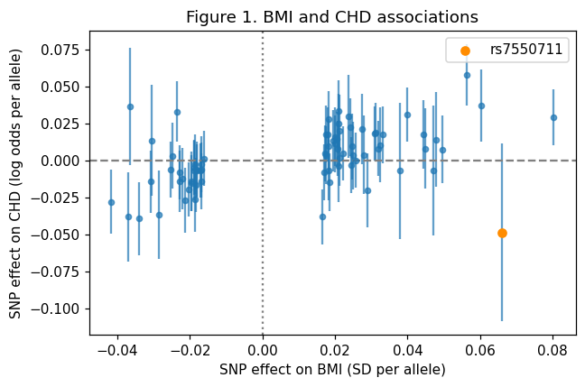

```python
plt.figure(figsize=(6, 4))

# Vertical bars show approximate 95% intervals for CHD effects.
plt.errorbar(bmi_effect, chd_effect, yerr=1.96 * chd_se,
             fmt='o', markersize=4, alpha=0.7)

# Highlight the SNP selected above.
plt.scatter(example_snp['bmi_effect'], example_snp['chd_effect'],
            color='darkorange', label=example_snp['snp'], zorder=3)
plt.legend()
plt.axhline(0, color='grey', linestyle='--')
plt.axvline(0, color='grey', linestyle=':')
plt.xlabel('SNP effect on BMI (SD per allele)')
plt.ylabel('SNP effect on CHD (log odds per allele)')
plt.title('Figure 1. BMI and CHD associations')
plt.tight_layout()
plt.show()
```

**Answer.** rs7550711 has BMI effect 0.0659 (SE 0.0087) and CHD effect −0.0484 (SE 0.0306). Its CHD interval, −0.1083 to 0.0116 log odds per allele, includes zero. It has both the most negative CHD estimate and the largest CHD standard error. The direction is uncertain.

## Q3. Estimate the effect using one SNP

The Wald ratio expresses the CHD effect per SD higher BMI:

$$\text{MR estimate} = \frac{\text{SNP effect on CHD}}{\text{SNP effect on BMI}}. \qquad (1)$$

`np.exp(...)` converts log odds to an odds ratio. Compare rows 0 and 2. Why do their estimates differ?

```python
snp_number = 0  # TRY: change to 2 (the orange point).
snp = data.iloc[snp_number]

single_snp_estimate = snp['chd_effect'] / snp['bmi_effect']
single_snp_odds_ratio = np.exp(single_snp_estimate)

print('SNP:', snp['snp'])

print(f'MR estimate: {single_snp_estimate:.3f} log odds per SD BMI')
print(f'Odds ratio: {single_snp_odds_ratio:.3f} per SD BMI')
```

```
SNP: rs977747
MR estimate: 0.827 log odds per SD BMI
Odds ratio: 2.287 per SD BMI
```

**Answer.** Row 0 gives 0.827 log odds per SD BMI (OR 2.287); row 2 gives −0.734 (OR 0.480). Both associations for row 0 are negative, giving a positive ratio. Sampling error and possibly invalid instruments make individual ratios vary. The wide interval for row 2's CHD association carries through to its ratio.

## Q4. Combine the SNPs

Inverse-variance weighting (IVW) gives more weight to precise ratio estimates:

$$\text{IVW estimate} = \frac{\sum_j \text{weight}_j\,\text{ratio}_j}{\sum_j \text{weight}_j}. \qquad (2)$$

We treat the SNPs as independent and uncertainty in the BMI effects as small. Halving a ratio's standard error gives it four times the weight. Why? Interpret the combined odds ratio.

```python
# Ratio estimates
snp_estimates = chd_effect / bmi_effect

# Approximate standard errors; abs keeps them positive.
snp_standard_errors = chd_se / np.abs(bmi_effect)

# Inverse-variance weights
weights = 1 / snp_standard_errors**2

# Weighted mean
mr_estimate = np.average(snp_estimates, weights=weights)

print(f'IVW estimate: {mr_estimate:.3f} log odds per SD BMI')
print(f'Odds ratio: {np.exp(mr_estimate):.3f} per SD BMI')
```

```
IVW estimate: 0.433 log odds per SD BMI
Odds ratio: 1.542 per SD BMI
```

**Answer.** Halving the standard error quarters the variance, so its inverse is four times larger. IVW gives OR 1.542 per SD higher BMI: about 54% higher CHD odds under the MR assumptions. This is not automatically the effect of a weight-loss treatment.

## Q5. Calculate a confidence interval

`Q` measures disagreement between SNP estimates. With 75 SNPs and one fitted effect, its expected value under the common-effect model is about 74. Excess disagreement widens the interval; it does not remove bias from invalid instruments.

Does the approximate 95% interval include an odds ratio of one? What assumptions are needed for a causal interpretation?

```python
# Weighted disagreement between SNP estimates.
residuals = snp_estimates - mr_estimate

Q = np.sum(weights * residuals**2)
expected_Q = len(data) - 1

variance_inflation = max(1, Q / expected_Q)  # Never shrink the interval.

# Allow for extra disagreement, then calculate the 95% interval.
standard_error = 1 / np.sqrt(weights.sum())

mr_standard_error = standard_error * np.sqrt(variance_inflation)

lower_limit = mr_estimate - 1.96 * mr_standard_error
upper_limit = mr_estimate + 1.96 * mr_standard_error

print(f'Variance inflation from SNP disagreement: {variance_inflation:.2f}')
print(f'Odds ratio: {np.exp(mr_estimate):.3f}')

print(f'95% interval: {np.exp(lower_limit):.3f} to {np.exp(upper_limit):.3f}')
```

```
Variance inflation from SNP disagreement: 1.86
Odds ratio: 1.542
95% interval: 1.370 to 1.735
```

**Answer.** The adjusted interval is 1.370–1.735, excluding one. Variance inflation is about 1.86. A causal interpretation still requires valid instruments and compatible GWAS populations. LD, sample overlap, selection and exposure uncertainty also matter; the interval does not test these assumptions.

## Q6. Add pleiotropy

Now simulate two continuous traits, with known SNP effects on the exposure. The outcome depends on a causal pathway and a second pathway proportional to the SNP's exposure effect. The second pathway represents horizontal pleiotropy. The MR estimate is in outcome units per exposure unit.

Try Table 3's settings, rerunning both cells each time. Figure 2 shows the associations and IVW fit (orange line).

Table 3. Simulation settings.

| Setting | `causal_effect` | `pleiotropy` |
| --- | --- | --- |
| A: causal effect only | 0.3 | 0.0 |
| B: causal effect plus pleiotropy | 0.3 | 0.2 |
| C: pleiotropy only | 0.0 | 0.3 |

Why do A and C give identical results? Which MR assumption fails in C?

```python
causal_effect = 0.3  # TRY: the settings in Table 3.
pleiotropy = 0.0    # TRY: the settings in Table 3.

# Keep the random noise the same when changing the settings.
rng = np.random.default_rng(20261008)
exposure_effect = np.linspace(0.04, 0.12, 30)  # Known effects for 30 SNPs.
outcome_se = np.full(30, 0.012)

noise = rng.normal(0, outcome_se)

causal_path = causal_effect * exposure_effect  # Through the exposure.
other_path = pleiotropy * exposure_effect     # Through another pathway.
outcome_effect = causal_path + other_path + noise
```

```
True causal effect: 0.300; MR estimate: 0.351
```

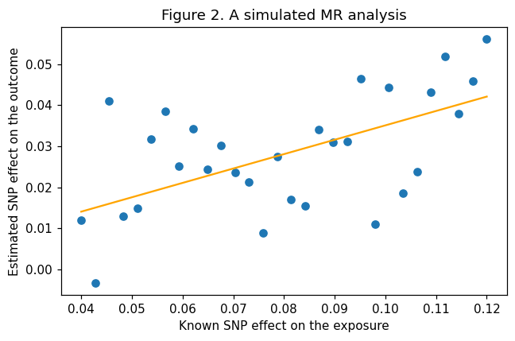

```python
# Same IVW calculation as Q4.
simulated_ratios = outcome_effect / exposure_effect
simulated_standard_errors = outcome_se / np.abs(exposure_effect)
simulated_weights = 1 / simulated_standard_errors**2
simulated_estimate = np.average(simulated_ratios, weights=simulated_weights)
print(f'True causal effect: {causal_effect:.3f}; MR estimate: {simulated_estimate:.3f}')

plt.figure(figsize=(6, 4))
plt.scatter(exposure_effect, outcome_effect)

plt.plot(exposure_effect, simulated_estimate * exposure_effect, color='orange')
plt.xlabel('Known SNP effect on the exposure')
plt.ylabel('Estimated SNP effect on the outcome')
plt.title('Figure 2. A simulated MR analysis')
plt.tight_layout()
plt.show()
```

**Answer.** The association slope is `causal_effect + pleiotropy`. A and C both give 0.3 and use identical noise, so the data and estimates match. B has slope 0.5 despite a true causal effect of 0.3. C violates exclusion: the SNPs affect the outcome outside the exposure pathway. This constructed example does not establish what happens in the real BMI–CHD data.

## Q7. Conclude

Write three sentences: report the BMI–CHD estimate and interval with units, state the main assumption you cannot verify, and suggest another study that could test the conclusion.

**Answer.** IVW estimates OR 1.54 per SD higher BMI (95% CI 1.37–1.74), conditional on valid instruments and the working model. The association pattern cannot establish the exclusion restriction. An intervention affecting adiposity could help test the conclusion, allowing for differences in timing, duration and other intervention effects.

## Data and method notes

The data are a frozen [TwoSampleMR example](https://github.com/MRCIEU/TwoSampleMR/blob/f4920457ee65c279f17c9a891173239d6adcd52c/vignettes/harmonise.Rmd): [Locke et al. (2015), BMI](https://pubmed.ncbi.nlm.nih.gov/25673413/), and [Nikpay et al. (2015), CHD](https://pubmed.ncbi.nlm.nih.gov/26343387/). BMI was studied in up to 339,224 participants; CHD in 60,801 cases and 123,504 controls. Both source datasets are labelled mixed ancestry.

The source workflow selects significant BMI associations and applies [LD clumping](https://github.com/MRCIEU/TwoSampleMR/blob/f4920457ee65c279f17c9a891173239d6adcd52c/R/instruments.R). Of 79 matched SNPs, we exclude four palindromic A/T or C/G variants and retain the original GWAS effect alleles and signed effects for the remaining 75. BMI and CHD allele labels match. Raw data and preparation details are in `data/`.

We use first-order IVW and a multiplicative random-effects interval, treating SNPs as independent and exposure effects as precisely estimated. Proxy substitutions and participant overlap have not been independently audited. A genetic contrast is not automatically equivalent to a treatment.

Background: [Burgess et al. (2013), summary-data MR](https://pubmed.ncbi.nlm.nih.gov/24114802/); [Hemani et al. (2018), MR-Base](https://doi.org/10.7554/eLife.34408); [Morrison et al. (2020), correlated pleiotropy](https://www.nature.com/articles/s41588-020-0631-4).